# Virus Titer Analysis App

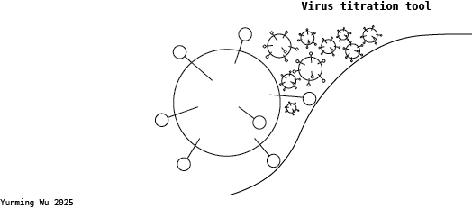

Virus titration tool

## How to use

### Prerequisites:

You need to have R and RStudio installed on your computer. The app also requires the following R packages: shiny ggplot2 DT. The app has a built-in check to automatically install any missing packages. However, you can manually install them by running this command in your R console: install.packages(c(“shiny”, “ggplot2”, “DT”))

### Download:

First download the entire folder to your local computer.

### Run the App:

Open the app.R file in RStudio and click the “Run App” button at the top-right of the script editor.

### In the app:

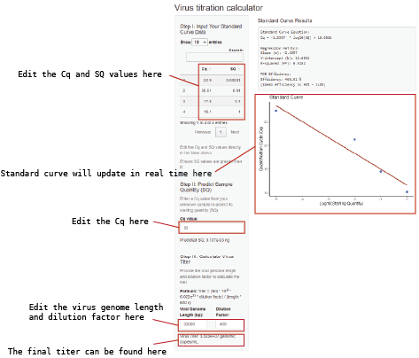

app interface

#### Step I: Input Your Standard Curve Data

An editable table where you can enter the Cq and SQ values from your standard curve.

#### Step II: Predict Sample Quantity (SQ)

Enter the Cq value of your unknown sample. The app will display the predicted starting quantity (SQ) of that sample.

#### Step III: Calculate Virus Titer

Enter the viral genome length (in base pairs) and the dilution factor. The app will display the final calculated virus titer in “genomic copies/mL”.

## How It Works

The app uses the following formulas for its calculations:

Standard Curve Equation: y=mx+b where y is the Cq value and x is the log10(SQ).

SQ: The predicted starting quantity of the sample.